# Лабораторная работа: Импорт и профилирование данных

Болдин А.В. ДМ-2271

```r
library(tidyverse)
library(janitor)
library(skimr)
library(visdat)
library(DataExplorer)
```

# 1. Описание данных и цель работы

Цель работы - импортировать набор данных с типичными дефектами, проверить корректность типов и выявить проблемы качества данных с помощью профилирования.

Основной набор данных - Air Quality из UCI Machine Learning Repository. Он содержит почасовые показания газовых датчиков и метеорологические параметры.

В этой работе выполняется диагностика качества данных и составляется план очистки.

# 2. Изучение сырого файла

Сначала изучим исходный CSV-файл как обычный текст, не преобразуя его в таблицу.

## 2.1. Первые и последние строки

```r
read_lines("data/raw/AirQualityUCI.csv", n_max = 5)
```

```
## [1] "Date;Time;CO(GT);PT08.S1(CO);NMHC(GT);C6H6(GT);PT08.S2(NMHC);NOx(GT);PT08.S3(NOx);NO2(GT);PT08.S4(NO2);PT08.S5(O3);T;RH;AH;;"
## [2] "10/03/2004;18.00.00;2,6;1360;150;11,9;1046;166;1056;113;1692;1268;13,6;48,9;0,7578;;"
## [3] "10/03/2004;19.00.00;2;1292;112;9,4;955;103;1174;92;1559;972;13,3;47,7;0,7255;;"
## [4] "10/03/2004;20.00.00;2,2;1402;88;9,0;939;131;1140;114;1555;1074;11,9;54,0;0,7502;;"
## [5] "10/03/2004;21.00.00;2,2;1376;80;9,2;948;172;1092;122;1584;1203;11,0;60,0;0,7867;;"
```

```r
read_lines("data/raw/AirQualityUCI.csv", skip = 9355, n_max = 5)
```

```
## [1] "04/04/2005;12.00.00;2,4;1142;-200;12,4;1063;293;603;175;1241;1092;26,9;18,3;0,6406;;"
## [2] "04/04/2005;13.00.00;2,1;1003;-200;9,5;961;235;702;156;1041;770;28,3;13,5;0,5139;;"
## [3] "04/04/2005;14.00.00;2,2;1071;-200;11,9;1047;265;654;168;1129;816;28,5;13,1;0,5028;;"
## [4] ";;;;;;;;;;;;;;;;"
## [5] ";;;;;;;;;;;;;;;;"
```

## 2.2. Определение кодировки

```r
guess_encoding("data/raw/AirQualityUCI.csv")
```

```
## # A tibble: 1 × 2
##   encoding confidence
##   <chr>         <dbl>
## 1 ASCII             1
```

## 2.3. Параметры файла

| Параметр | Найденное значение | Чем подтверждено |
| --- | --- | --- |
| Разделитель | Точка с запятой (;) | Первые строки файла |
| Десятичный знак | Запятая (,) | Значения 2,6 и 11,9 |
| Кодировка | ASCII | guess_encoding(), уверенность 1 |
| Служебные строки | 0 | Заголовки находятся в первой строке |
| Обозначение пропусков | -200 | Обнаружено в данных |
| Пустые столбцы | 2 | Два разделителя в конце строк |
| Пустые записи | Присутствуют | Строки из разделителей в конце файла |

# 3. Импорт основного набора данных

Для импорта используется функция `read_csv2()`, которая учитывает разделитель `;` и десятичную запятую.

Значения `-200`, `NA` и пустые ячейки интерпретируются как пропущенные значения.

Столбцы `Date` и `Time` считываются как текстовые для последующего преобразования.

```r
df_raw <- read_csv2(
  "data/raw/AirQualityUCI.csv",
  na = c("", "NA", "-200", "-200,0"),
  col_types = cols(
    Date = col_character(),
    Time = col_character()
  )
)
```

```
## ℹ Using "','" as decimal and "'.'" as grouping mark. Use `read_delim()` for more control.
```

```r
glimpse(df_raw)
```

```
## Rows: 9,471
## Columns: 17
## $ Date            <chr> "10/03/2004", "10/03/2004", "10/03/2004", "10/03/2004"…
## $ Time            <chr> "18.00.00", "19.00.00", "20.00.00", "21.00.00", "22.00…
## $ `CO(GT)`        <dbl> 2.6, 2.0, 2.2, 2.2, 1.6, 1.2, 1.2, 1.0, 0.9, 0.6, NA, …
## $ `PT08.S1(CO)`   <dbl> 1360, 1292, 1402, 1376, 1272, 1197, 1185, 1136, 1094, …
## $ `NMHC(GT)`      <dbl> 150, 112, 88, 80, 51, 38, 31, 31, 24, 19, 14, 8, 16, 2…
## $ `C6H6(GT)`      <dbl> 11.9, 9.4, 9.0, 9.2, 6.5, 4.7, 3.6, 3.3, 2.3, 1.7, 1.3…
## $ `PT08.S2(NMHC)` <dbl> 1046, 955, 939, 948, 836, 750, 690, 672, 609, 561, 527…
## $ `NOx(GT)`       <dbl> 166, 103, 131, 172, 131, 89, 62, 62, 45, NA, 21, 16, 3…
## $ `PT08.S3(NOx)`  <dbl> 1056, 1174, 1140, 1092, 1205, 1337, 1462, 1453, 1579, …
## $ `NO2(GT)`       <dbl> 113, 92, 114, 122, 116, 96, 77, 76, 60, NA, 34, 28, 48…
## $ `PT08.S4(NO2)`  <dbl> 1692, 1559, 1555, 1584, 1490, 1393, 1333, 1333, 1276, …
## $ `PT08.S5(O3)`   <dbl> 1268, 972, 1074, 1203, 1110, 949, 733, 730, 620, 501, …
## $ T               <dbl> 13.6, 13.3, 11.9, 11.0, 11.2, 11.2, 11.3, 10.7, 10.7, …
## $ RH              <dbl> 48.9, 47.7, 54.0, 60.0, 59.6, 59.2, 56.8, 60.0, 59.7, …
## $ AH              <dbl> 0.7578, 0.7255, 0.7502, 0.7867, 0.7888, 0.7848, 0.7603…
## $ ...16           <lgl> NA, NA, NA, NA, NA, NA, NA, NA, NA, NA, NA, NA, NA, NA…
## $ ...17           <lgl> NA, NA, NA, NA, NA, NA, NA, NA, NA, NA, NA, NA, NA, NA…
```

```r
spec(df_raw)
problems(df_raw)
```

```
## # A tibble: 0 × 5
## # ℹ 5 variables: row <int>, col <int>, expected <chr>, actual <chr>, file <chr>
```

```r
sapply(df_raw, function(x) {
  if (is.numeric(x)) sum(x == -200, na.rm = TRUE) else NA_integer_
})
```

```
##          Date          Time        CO(GT)   PT08.S1(CO)      NMHC(GT)
##            NA            NA             0             0             0
##      C6H6(GT) PT08.S2(NMHC)       NOx(GT)  PT08.S3(NOx)       NO2(GT)
##             0             0             0             0             0
##  PT08.S4(NO2)   PT08.S5(O3)             T            RH            AH
##             0             0             0             0             0
##         ...16         ...17
##            NA            NA
```

## 3.1. Результаты импорта

Для загрузки данных использована функция `read_csv2()`, которая учитывает разделитель `;` и десятичную запятую. Без этих параметров данные могли бы импортироваться некорректно.

Параметр `na = c("", "NA", "-200", "-200,0")` позволяет распознавать разные обозначения пропущенных значений. Без него значения `-200` и `-200,0` могли бы интерпретироваться как обычные числа и искажать статистические показатели.

Параметр `col_types` задаёт текстовый тип для столбцов `Date` и `Time`, чтобы избежать их некорректного автоматического преобразования.

После импорта получена таблица из 9471 строки и 17 столбцов. Столбцы `Date` и `Time` имеют текстовый тип, основные числовые показатели - тип `double`. Два последних столбца (`...16` и `...17`) полностью пустые.

Функция `problems()` не обнаружила ошибок разбора данных.

Таким образом, данные успешно импортированы, однако в таблице остаются проблемы качества, которые необходимо исследовать на следующих этапах.

# 4. Импорт файла с проблемной кодировкой

## 4.1. Импорт с параметрами по умолчанию

Сначала попробуем загрузить файл без дополнительных настроек.

```r
tryCatch({
  meteo_default <- read_csv2(
    "data/raw/meteo.csv",
    show_col_types = FALSE
  )

  print(head(meteo_default, 5))

}, error = function(e) {
  cat("Ошибка при импорте или выводе данных:\n")
  cat(conditionMessage(e))
})
```

```
## ℹ Using "','" as decimal and "'.'" as grouping mark. Use `read_delim()` for more control.
```

```
## # A tibble: 5 × 1
## Ошибка при импорте или выводе данных:
## неправильная многобайтная строка в '<d4><e5><e4><e5>'
```

```r
meteo_default <- suppressWarnings(
  read_csv2("data/raw/meteo.csv", show_col_types = FALSE)
)
```

```
## ℹ Using "','" as decimal and "'.'" as grouping mark. Use `read_delim()` for more control.
```

```r
preview_before <- tibble(
  Строка = 1:5,
  Содержимое = iconv(
    meteo_default[[1]][1:5],
    from = "Windows-1251",
    to = "UTF-8",
    sub = "byte"
  )
)

knitr::kable(preview_before)
```

| Строка | Содержимое |
| --- | --- |
| 1 | Выгрузка: 15.03.2025, оператор: Иванов И.И. |
| 2 | Единицы: температура — °C, давление — гПа, влажность — %, осадки — мм |
| 3 | # Примечание: н/д — нет данных; -999 — сбой датчика |
| 4 | Станция;Дата;Температура, °C;Давление, гПа;Влажность, %;Осадки, мм;Направление ветра |
| 5 | Москва-ВДНХ;01.03.2025;-1,4;1000,9;68;0,4;З |

## 4.2. Корректный импорт

Для корректной загрузки указываем кодировку Windows-1251, пропускаем четыре служебные строки и исключаем комментарии.

```r
# Читаем файл как текст с правильной кодировкой
meteo_lines <- read_lines(
  "data/raw/meteo.csv",
  locale = locale(encoding = "Windows-1251")
)

# Импортируем уже декодированный текст
meteo <- read_csv2(
  I(paste(meteo_lines, collapse = "\n")),
  skip = 4,
  comment = "#",
  na = c("", "NA", "н/д", "-999"),
  show_col_types = FALSE
)
```

```
## ℹ Using "','" as decimal and "'.'" as grouping mark. Use `read_delim()` for more control.
```

```r
head(meteo, 5)
```

```
## # A tibble: 5 × 7
##   Станция    Дата  `Температура, °C` `Давление, гПа` `Влажность, %` `Осадки, мм`
##   <chr>      <chr>             <dbl>           <dbl>          <dbl>        <dbl>
## 1 Москва-ВД… 01.0…              -1.4           1001.             68          0.4
## 2 Москва-ВД… 02.0…               1.2           1004.             72          0
## 3 Москва-ВД… 03.0…               2.4           1007.             77          0
## 4 Москва-ВД… 04.0…               1.7           1005.             72          0.8
## 5 Москва-ВД… 05.0…              -2.3           1012.             70          0
## # ℹ 1 more variable: `Направление ветра` <chr>
```

```r
glimpse(meteo)
```

```
## Rows: 50
## Columns: 7
## $ Станция             <chr> "Москва-ВДНХ", "Москва-ВДНХ", "Москва-ВДНХ", "Моск…
## $ Дата                <chr> "01.03.2025", "02.03.2025", "03.03.2025", "04.03.2…
## $ `Температура, °C`   <dbl> -1.4, 1.2, 2.4, 1.7, -2.3, 0.4, 2.6, 3.3, 0.0, 0.1…
## $ `Давление, гПа`     <dbl> 1000.9, 1003.7, 1007.1, 1005.2, 1011.6, 1003.4, 10…
## $ `Влажность, %`      <dbl> 68, 72, 77, 72, 70, 75, 83, 80, 78, 76, 90, 87, 75…
## $ `Осадки, мм`        <dbl> 0.4, 0.0, 0.0, 0.8, 0.0, 0.0, 0.0, 0.0, 0.0, 0.0, …
## $ `Направление ветра` <chr> "З", "З", "ЮВ", "З", "СВ", "ЮЗ", "СЗ", "СЗ", "З", …
```

```r
problems(meteo)
```

```
## # A tibble: 0 × 5
## # ℹ 5 variables: row <int>, col <int>, expected <chr>, actual <chr>, file <chr>
```

```r
knitr::kable(head(meteo, 5))
```

| Станция | Дата | Температура, °C | Давление, гПа | Влажность, % | Осадки, мм | Направление ветра |
| --- | --- | --- | --- | --- | --- | --- |
| Москва-ВДНХ | 01.03.2025 | -1.4 | 1000.9 | 68 | 0.4 | З |
| Москва-ВДНХ | 02.03.2025 | 1.2 | 1003.7 | 72 | 0.0 | З |
| Москва-ВДНХ | 03.03.2025 | 2.4 | 1007.1 | 77 | 0.0 | ЮВ |
| Москва-ВДНХ | 04.03.2025 | 1.7 | 1005.2 | 72 | 0.8 | З |
| Москва-ВДНХ | 05.03.2025 | -2.3 | 1011.6 | 70 | 0.0 | СВ |

## 4.3. Результаты импорта

При импорте с параметрами по умолчанию возникли проблемы с кодировкой и структурой таблицы. Вместо семи столбцов получился один, а вывод данных завершался ошибкой.

Для корректного импорта использованы следующие параметры:

- `encoding = "Windows-1251"` - кодировка исходного файла;
- `skip = 4` - пропуск служебных строк;
- `comment = "#"` - исключение комментариев;
- `na = c("", "NA", "н/д", "-999")` - обозначения пропусков.

После предварительного декодирования текста получена таблица из 50 строк и 7 столбцов. Функция `problems()` не обнаружила ошибок разбора данных.

Первые пять строк до и после корректного импорта приведены выше.

# 5. Имена, пустые строки и типы данных

## 5.1. Приведение названий столбцов

Приведём названия столбцов к единому стилю с помощью функции `clean_names()`.

```r
df <- clean_names(df_raw)

names_comparison <- tibble(
  before = names(df_raw),
  after = names(df)
)

knitr::kable(names_comparison)
```

| before | after |
| --- | --- |
| Date | date |
| Time | time |
| CO(GT) | co_gt |
| PT08.S1(CO) | pt08_s1_co |
| NMHC(GT) | nmhc_gt |
| C6H6(GT) | c6h6_gt |
| PT08.S2(NMHC) | pt08_s2_nmhc |
| NOx(GT) | n_ox_gt |
| PT08.S3(NOx) | pt08_s3_n_ox |
| NO2(GT) | no2_gt |
| PT08.S4(NO2) | pt08_s4_no2 |
| PT08.S5(O3) | pt08_s5_o3 |
| T | t |
| RH | rh |
| AH | ah |
| …16 | x16 |
| …17 | x17 |

## 5.2. Удаление пустых строк и столбцов

Удалим полностью пустые строки и столбцы с помощью функции `remove_empty()`.

```r
dim_before <- dim(df)

# Удаление пустых строк и столбцов
df <- df %>%
  remove_empty(which = "rows") %>%
  remove_empty(which = "cols")

dim_after <- dim(df)

# Таблица сравнения
comparison <- tibble(
  Показатель = c("Количество строк", "Количество столбцов"),
  До = dim_before,
  После = dim_after,
  Удалено = dim_before - dim_after
)

knitr::kable(comparison)
```

| Показатель | До | После | Удалено |
| --- | --- | --- | --- |
| Количество строк | 9471 | 9357 | 114 |
| Количество столбцов | 17 | 15 | 2 |

После удаления полностью пустых строк и столбцов размер таблицы сократился с 9471 до 9357 строк и с 17 до 15 столбцов. Удалены 114 пустых строк и 2 пустых столбца.

## 5.3. Преобразование даты и времени

Объединим столбцы `date` и `time` в единую метку времени с помощью `parse_date_time()`. Для преобразования используем часовой пояс UTC.

```r
df <- df %>%
  mutate(
    timestamp = parse_date_time(
      paste(date, gsub("\\.", ":", time)),
      orders = "dmy HMS",
      tz = "UTC"
    )
  )

# Проверка количества ошибок преобразования
sum(is.na(df$timestamp))
```

```
## [1] 0
```

```r
# Проверка итоговых типов
glimpse(df)
```

```
## Rows: 9,357
## Columns: 16
## $ date         <chr> "10/03/2004", "10/03/2004", "10/03/2004", "10/03/2004", "…
## $ time         <chr> "18.00.00", "19.00.00", "20.00.00", "21.00.00", "22.00.00…
## $ co_gt        <dbl> 2.6, 2.0, 2.2, 2.2, 1.6, 1.2, 1.2, 1.0, 0.9, 0.6, NA, 0.7…
## $ pt08_s1_co   <dbl> 1360, 1292, 1402, 1376, 1272, 1197, 1185, 1136, 1094, 101…
## $ nmhc_gt      <dbl> 150, 112, 88, 80, 51, 38, 31, 31, 24, 19, 14, 8, 16, 29, …
## $ c6h6_gt      <dbl> 11.9, 9.4, 9.0, 9.2, 6.5, 4.7, 3.6, 3.3, 2.3, 1.7, 1.3, 1…
## $ pt08_s2_nmhc <dbl> 1046, 955, 939, 948, 836, 750, 690, 672, 609, 561, 527, 5…
## $ n_ox_gt      <dbl> 166, 103, 131, 172, 131, 89, 62, 62, 45, NA, 21, 16, 34, …
## $ pt08_s3_n_ox <dbl> 1056, 1174, 1140, 1092, 1205, 1337, 1462, 1453, 1579, 170…
## $ no2_gt       <dbl> 113, 92, 114, 122, 116, 96, 77, 76, 60, NA, 34, 28, 48, 8…
## $ pt08_s4_no2  <dbl> 1692, 1559, 1555, 1584, 1490, 1393, 1333, 1333, 1276, 123…
## $ pt08_s5_o3   <dbl> 1268, 972, 1074, 1203, 1110, 949, 733, 730, 620, 501, 445…
## $ t            <dbl> 13.6, 13.3, 11.9, 11.0, 11.2, 11.2, 11.3, 10.7, 10.7, 10.…
## $ rh           <dbl> 48.9, 47.7, 54.0, 60.0, 59.6, 59.2, 56.8, 60.0, 59.7, 60.…
## $ ah           <dbl> 0.7578, 0.7255, 0.7502, 0.7867, 0.7888, 0.7848, 0.7603, 0…
## $ timestamp    <dttm> 2004-03-10 18:00:00, 2004-03-10 19:00:00, 2004-03-10 20:…
```

Все 9357 значений даты и времени успешно преобразованы в формат POSIXct. Количество пропусков в столбце `timestamp` равно 0.

После преобразования таблица содержит 9357 строк и 16 столбцов. Текстовые столбцы `date` и `time` сохранены, остальные исходные показатели имеют числовой тип.

Часовой пояс UTC выбран условно, поскольку исходный файл не содержит информации о часовом поясе.

# 6. Профилирование данных

## 6.1. Общая статистика

Для изучения характеристик столбцов используем функцию `skim()`.

```r
skim(df)
```

Data summary

| Name | df |
| --- | --- |
| Number of rows | 9357 |
| Number of columns | 16 |
| _______________________ |  |
| Column type frequency: |  |
| character | 2 |
| numeric | 13 |
| POSIXct | 1 |
| ________________________ |  |
| Group variables | None |

**Variable type: character**

| skim_variable | n_missing | complete_rate | min | max | empty | n_unique | whitespace |
| --- | --- | --- | --- | --- | --- | --- | --- |
| date | 0 | 1 | 10 | 10 | 0 | 391 | 0 |
| time | 0 | 1 | 8 | 8 | 0 | 24 | 0 |

**Variable type: numeric**

| skim_variable | n_missing | complete_rate | mean | sd | p0 | p25 | p50 | p75 | p100 | hist |
| --- | --- | --- | --- | --- | --- | --- | --- | --- | --- | --- |
| co_gt | 1683 | 0.82 | 2.15 | 1.45 | 0.10 | 1.10 | 1.8 | 2.90 | 11.90 | ▇▃▁▁▁ |
| pt08_s1_co | 366 | 0.96 | 1099.83 | 217.08 | 647.00 | 937.00 | 1063.0 | 1231.00 | 2040.00 | ▃▇▃▁▁ |
| nmhc_gt | 8443 | 0.10 | 218.81 | 204.46 | 7.00 | 67.00 | 150.0 | 297.00 | 1189.00 | ▇▂▁▁▁ |
| c6h6_gt | 366 | 0.96 | 10.08 | 7.45 | 0.10 | 4.40 | 8.2 | 14.00 | 63.70 | ▇▃▁▁▁ |
| pt08_s2_nmhc | 366 | 0.96 | 939.15 | 266.83 | 383.00 | 734.50 | 909.0 | 1116.00 | 2214.00 | ▅▇▃▁▁ |
| n_ox_gt | 1639 | 0.82 | 246.90 | 212.98 | 2.00 | 98.00 | 180.0 | 326.00 | 1479.00 | ▇▂▁▁▁ |
| pt08_s3_n_ox | 366 | 0.96 | 835.49 | 256.82 | 322.00 | 658.00 | 806.0 | 969.50 | 2683.00 | ▇▇▁▁▁ |
| no2_gt | 1642 | 0.82 | 113.09 | 48.37 | 2.00 | 78.00 | 109.0 | 142.00 | 340.00 | ▃▇▃▁▁ |
| pt08_s4_no2 | 366 | 0.96 | 1456.26 | 346.21 | 551.00 | 1227.00 | 1463.0 | 1674.00 | 2775.00 | ▂▇▇▂▁ |
| pt08_s5_o3 | 366 | 0.96 | 1022.91 | 398.48 | 221.00 | 731.50 | 963.0 | 1273.50 | 2523.00 | ▃▇▅▂▁ |
| t | 366 | 0.96 | 18.32 | 8.83 | -1.90 | 11.80 | 17.8 | 24.40 | 44.60 | ▂▇▇▃▁ |
| rh | 366 | 0.96 | 49.23 | 17.32 | 9.20 | 35.80 | 49.6 | 62.50 | 88.70 | ▂▆▇▆▂ |
| ah | 366 | 0.96 | 1.03 | 0.40 | 0.18 | 0.74 | 1.0 | 1.31 | 2.23 | ▃▇▇▃▁ |

**Variable type: POSIXct**

| skim_variable | n_missing | complete_rate | min | max | median | n_unique |
| --- | --- | --- | --- | --- | --- | --- |
| timestamp | 0 | 1 | 2004-03-10 18:00:00 | 2005-04-04 14:00:00 | 2004-09-21 16:00:00 | 9357 |

Наиболее серьёзная проблема - большое количество пропусков в столбце `nmhc_gt` (90,23%). В столбцах `co_gt`, `n_ox_gt` и `no2_gt` отсутствует около 18% значений.

У остальных числовых показателей доля пропусков составляет 3,91%. Одинаковое количество пропусков в нескольких столбцах требует дополнительной проверки.

Столбец `timestamp` не содержит пропусков и имеет 9357 уникальных значений.

Дополнительной проверки требуют диапазоны значений в столбцах `c6h6_gt` (0,1-63,7), `n_ox_gt` (2-1479) и `pt08_s3_n_ox` (322-2683). Высокие максимальные значения могут указывать на выбросы, однако без дополнительной проверки считать их ошибками нельзя.

## 6.2. Полнота данных по столбцам

Рассчитаем количество и долю пропущенных значений для каждого столбца.

```r
missing_summary <- tibble(
  Столбец = names(df),
  Пропусков = colSums(is.na(df)),
  `Доля пропусков, %` = round(colMeans(is.na(df)) * 100, 2)
) %>%
  mutate(
    Комментарий = case_when(
      `Доля пропусков, %` == 0 ~ "Пропусков нет",
      `Доля пропусков, %` > 50 ~ "Очень много пропусков",
      `Доля пропусков, %` > 10 ~ "Значительная доля пропусков",
      TRUE ~ "Небольшая доля пропусков"
    )
  )

knitr::kable(missing_summary)
```

| Столбец | Пропусков | Доля пропусков, % | Комментарий |
| --- | --- | --- | --- |
| date | 0 | 0.00 | Пропусков нет |
| time | 0 | 0.00 | Пропусков нет |
| co_gt | 1683 | 17.99 | Значительная доля пропусков |
| pt08_s1_co | 366 | 3.91 | Небольшая доля пропусков |
| nmhc_gt | 8443 | 90.23 | Очень много пропусков |
| c6h6_gt | 366 | 3.91 | Небольшая доля пропусков |
| pt08_s2_nmhc | 366 | 3.91 | Небольшая доля пропусков |
| n_ox_gt | 1639 | 17.52 | Значительная доля пропусков |
| pt08_s3_n_ox | 366 | 3.91 | Небольшая доля пропусков |
| no2_gt | 1642 | 17.55 | Значительная доля пропусков |
| pt08_s4_no2 | 366 | 3.91 | Небольшая доля пропусков |
| pt08_s5_o3 | 366 | 3.91 | Небольшая доля пропусков |
| t | 366 | 3.91 | Небольшая доля пропусков |
| rh | 366 | 3.91 | Небольшая доля пропусков |
| ah | 366 | 3.91 | Небольшая доля пропусков |
| timestamp | 0 | 0.00 | Пропусков нет |

## 6.3. Визуальное профилирование

Для визуальной проверки типов данных и пропущенных значений используем пакет `visdat`.

### Типы данных

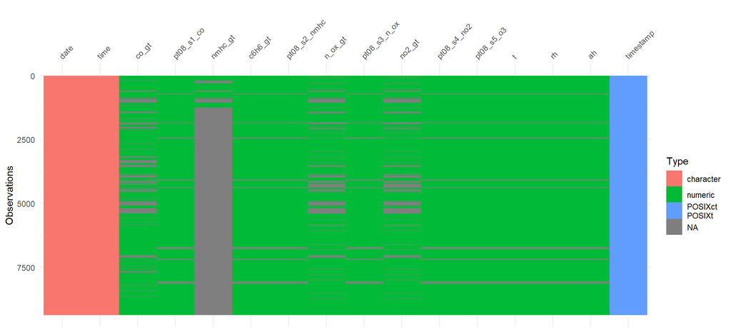

```r
vis_dat(df)
```

График показывает, что таблица содержит 2 текстовых столбца, 13 числовых и 1 столбец даты и времени. Серым цветом обозначены пропущенные значения. Наибольшее количество пропусков наблюдается в `nmhc_gt`.

### Распределение пропусков

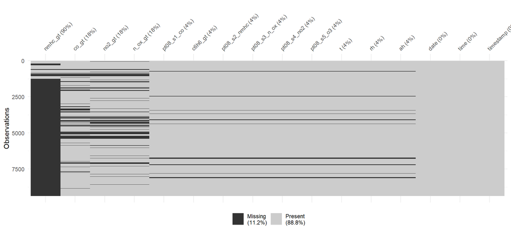

```r
vis_miss(df, sort_miss = TRUE)
```

Общая доля пропущенных ячеек составляет 11,2%. Наибольшая доля пропусков наблюдается в `nmhc_gt` (90,23%). В столбцах `co_gt`, `no2_gt` и `n_ox_gt` отсутствует около 18% значений.

Также заметны горизонтальные полосы пропусков, одновременно затрагивающие несколько столбцов. Это может указывать на периоды отсутствия измерений.

### Проверка допустимых значений

Проверим наличие отрицательных значений в показателях, которые не должны быть отрицательными. Температуру не включаем, поскольку отрицательные значения для нее допустимы.

```r
vis_expect(
  df %>% select(co_gt, c6h6_gt, n_ox_gt, no2_gt, rh, ah),
  ~.x >= 0
)
```

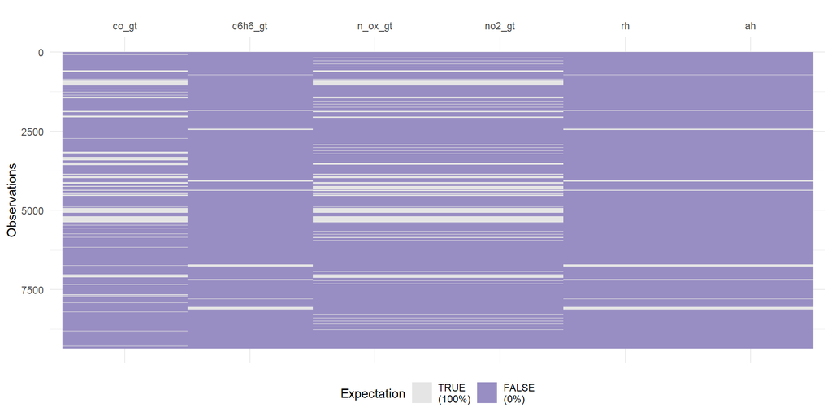

Проверка условия неотрицательности показала, что все имеющиеся значения выбранных показателей соответствуют допустимому диапазону. Пропуски и другие возможные аномалии требуют отдельной проверки.

## 6.4. Автоматический отчёт DataExplorer

Для дополнительного профилирования сформируем автоматический HTML-отчёт с помощью функции `create_report()`.

```r
create_report(
  df,
  output_file = "profile.html",
  report_title = "Профилирование Air Quality"
)
```

```
##
##
## processing file: report.rmd
```

[output not shown]

[output not shown]

[output not shown]

[output not shown]

[output not shown]

[output not shown]

[output not shown]

[output not shown]

```
## output file: C:/Users/arbol/OneDrive/Dokumente/data-cleaning-labs/lab2/report.knit.md
```

[output not shown]

```
##
## Output created: profile.html
```

Автоматический отчёт `profile.html` успешно сформирован с помощью DataExplorer. Он содержит информацию о структуре данных, пропусках, распределениях числовых показателей и взаимосвязях между ними.

## 6.5. Проверка дубликатов и частот

Проверим наличие полностью одинаковых строк с помощью `get_dupes()`.

```r
duplicates <- get_dupes(df)
```

```
## No variable names specified - using all columns.
```

```
## No duplicate combinations found of: date, time, co_gt, pt08_s1_co, nmhc_gt, c6h6_gt, pt08_s2_nmhc, n_ox_gt, pt08_s3_n_ox, ... and 7 other variables
```

```r
nrow(duplicates)
```

```
## [1] 0
```

```r
head(duplicates, 5)
```

```
## # A tibble: 0 × 17
## # ℹ 17 variables: date <chr>, time <chr>, co_gt <dbl>, pt08_s1_co <dbl>,
## #   nmhc_gt <dbl>, c6h6_gt <dbl>, pt08_s2_nmhc <dbl>, n_ox_gt <dbl>,
## #   pt08_s3_n_ox <dbl>, no2_gt <dbl>, pt08_s4_no2 <dbl>, pt08_s5_o3 <dbl>,
## #   t <dbl>, rh <dbl>, ah <dbl>, timestamp <dttm>, dupe_count <int>
```

Посмотрим распределение наблюдений по времени суток с помощью `count()`.

```r
df %>%
  count(time, sort = TRUE) %>%
  head(10)
```

```
## # A tibble: 10 × 2
##    time         n
##    <chr>    <int>
##  1 00.00.00   390
##  2 01.00.00   390
##  3 02.00.00   390
##  4 03.00.00   390
##  5 04.00.00   390
##  6 05.00.00   390
##  7 06.00.00   390
##  8 07.00.00   390
##  9 08.00.00   390
## 10 09.00.00   390
```

Полностью повторяющихся строк не обнаружено. Проверка частот показывает, что каждое из первых десяти значений времени суток встречается 390 раз, что соответствует почасовому характеру наблюдений.

# 7. Чек-лист и план очистки

В ходе импорта и профилирования были выявлены проблемы качества данных. В таблице представлены обнаруженные дефекты и предлагаемые способы их устранения.

| № | Где | Проблема | Чем подтверждено | Измерение качества | Предлагаемое решение |
| --- | --- | --- | --- | --- | --- |
| 1 | nmhc_gt | 8443 пропуска (90,23%) | skim(), vis_miss() | Полнота | Оценить возможность использования столбца или его исключения |
| 2 | co_gt | 1683 пропуска (17,99%) | skim() | Полнота | Исследовать характер пропусков и выбрать метод обработки |
| 3 | n_ox_gt | 1639 пропусков (17,52%) | skim() | Полнота | Проверить распределение пропусков во времени |
| 4 | no2_gt | 1642 пропуска (17,55%) | skim() | Полнота | Определить подходящий способ обработки пропусков |
| 5 | Основные числовые столбцы | По 366 пропусков в нескольких показателях | skim(), vis_miss() | Полнота | Проверить, совпадают ли периоды отсутствия измерений |
| 6 | Исходный CSV | 114 полностью пустых строк и 2 пустых столбца | remove_empty(), сравнение размеров | Структура | Удалять пустые строки и столбцы программно |
| 7 | Числовые показатели | Служебные значения -200 и -200,0 | Проверка sapply() | Корректность значений | Распознавать служебные коды как NA |
| 8 | date, time | Дата и время первоначально представлены текстом | glimpse() | Корректность типов | Создавать метку времени POSIXct |
| 9 | meteo.csv | Кодировка Windows-1251 и служебные строки мешают стандартному импорту | Ошибка импорта, problems() | Корректность формата | Указывать кодировку, skip и comment при импорте |

## 7.1. Вывод

Наиболее серьёзной проблемой является большое количество пропусков в столбце `nmhc_gt`, где отсутствует более 90% значений. Значительная доля пропусков также наблюдается в показателях `co_gt`, `n_ox_gt` и `no2_gt`.

При импорте были обнаружены служебные коды пропусков и проблемы структуры исходного файла. Для дальнейшей работы необходимо исследовать причины отсутствия измерений и определить подходящие методы очистки.

В рамках лабораторной выполнены импорт, структурная подготовка и профилирование данных. Содержательная очистка значений будет проводиться в следующих работах.

# 8. Контрольные вопросы

## 1. Какие измерения качества данных проверялись и какими инструментами?

Проверялись полнота, корректность типов и значений, структура данных и наличие дубликатов.

Использовались функции `skim()`, `vis_dat()`, `vis_miss()`, `vis_expect()`, `get_dupes()` и `problems()`, а также автоматический отчёт `DataExplorer`.

## 2. Почему readr может неверно определить тип столбца и как этого избежать?

`readr` автоматически определяет типы по содержимому данных. Если значения имеют нестандартный формат или содержат ошибки, тип может быть определён неправильно.

Для предотвращения ошибок можно явно задать типы с помощью `col_types`.

## 3. Чем опасны скрытые коды пропусков вроде -200?

Такие значения могут восприниматься как обычные числа и искажать средние значения, минимумы, распределения и результаты анализа.

При импорте их необходимо обозначать как пропущенные значения `NA`.

## 4. Почему get_dupes() не удаляет дубликаты автоматически?

Функция `get_dupes()` предназначена для поиска повторяющихся записей, а не для их удаления. Это позволяет сначала проверить дубликаты и принять решение об их обработке.

## 5. Чем отличается нарушение структуры tidy data от некорректных значений?

Нарушение структуры связано с неправильной организацией таблицы, например когда несколько переменных записаны в одном столбце.

Некорректные значения связаны с содержимым отдельных ячеек, например отрицательная влажность или служебный код пропуска вместо измерения.